# Tugas Praktikum 1 MPDW

# Metode Pemulusan Data Sunspot

## Data Preparation

### Import Library

```r
library("forecast")
```

```r
library("graphics")
library("TTR")
library("TSA")
library("rio")
library("readxl")
library("ggplot2")
```

### Import Data

```r
data_ss <- read_excel("C:/Users/user/Downloads/data_sunspot_darren.xlsx")
head(data_ss)
```

```
## # A tibble: 6 × 8
##    Year Month  Date `Decimal Date` `Sunspot Number` `Std Dev`
##   <dbl> <dbl> <dbl>          <dbl>            <dbl>     <dbl>
## 1  2025     3    19          2025.              165      16.5
## 2  2025     3    20          2025.              163      22.8
## 3  2025     3    21          2025.              151      27.6
## 4  2025     3    22          2025.              173      24.4
## 5  2025     3    23          2025.              126      24.3
## 6  2025     3    24          2025.               78      12.7
## # ℹ 2 more variables: `Total Obsevations` <dbl>,
## #   `Status (1 definitive, 0 provisional)` <dbl>
```

### Exploratory Data

```r
sunspot_ts <- ts(data_ss$`Sunspot Number`)

summary(sunspot_ts)
```

```
##    Min. 1st Qu.  Median    Mean 3rd Qu.    Max.
##   40.00   84.25  106.00  110.63  139.50  203.00
```

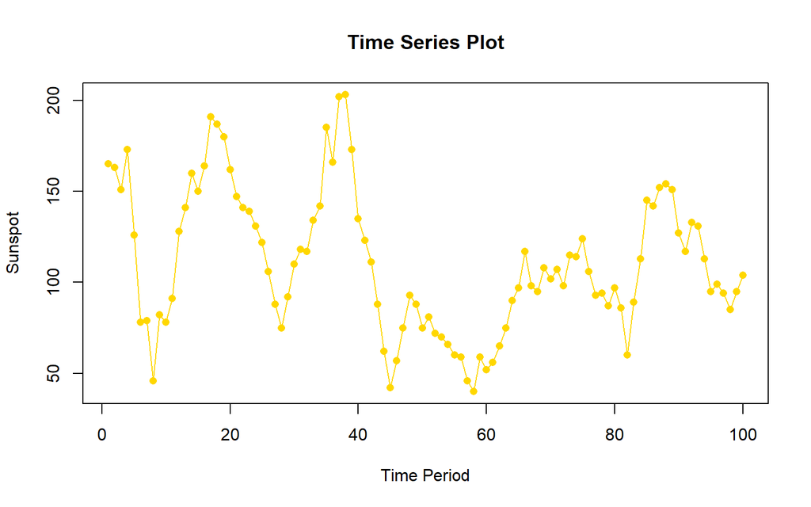

```r
ts.plot(sunspot_ts, col = "gold", xlab = "Time Period",
        ylab = "Sunspot", main = "Time Series Plot")

points(sunspot_ts, col = "gold", pch = 16)
```

# Split to Data Train and Data Test

```r
n <- nrow(data_ss)
n_train <- floor(0.8 * n)

training_ss <- data_ss[1:n_train, ]
testing_ss  <- data_ss[(n_train + 1):n, ]

train_ss.ts <- ts(training_ss$`Sunspot Number`)
test_ss.ts  <- ts(testing_ss$`Sunspot Number`)
```

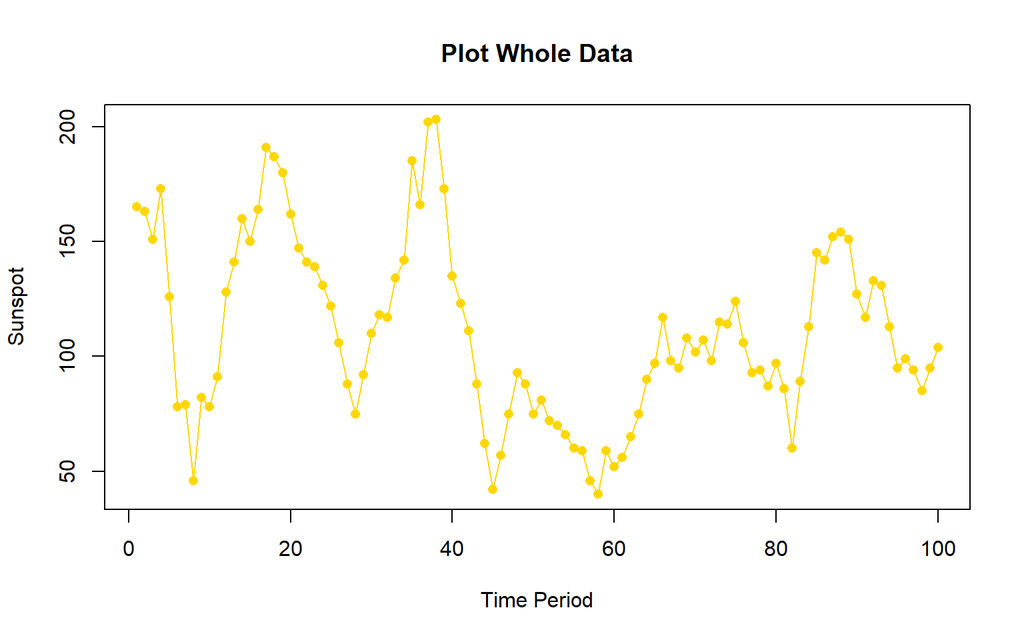

```r
ts.plot(sunspot_ts, col = "gold", xlab = "Time Period",
        ylab = "Sunspot", main = "Plot Whole Data")

points(sunspot_ts, col = "gold", pch = 16)
```

## Plot Data Train

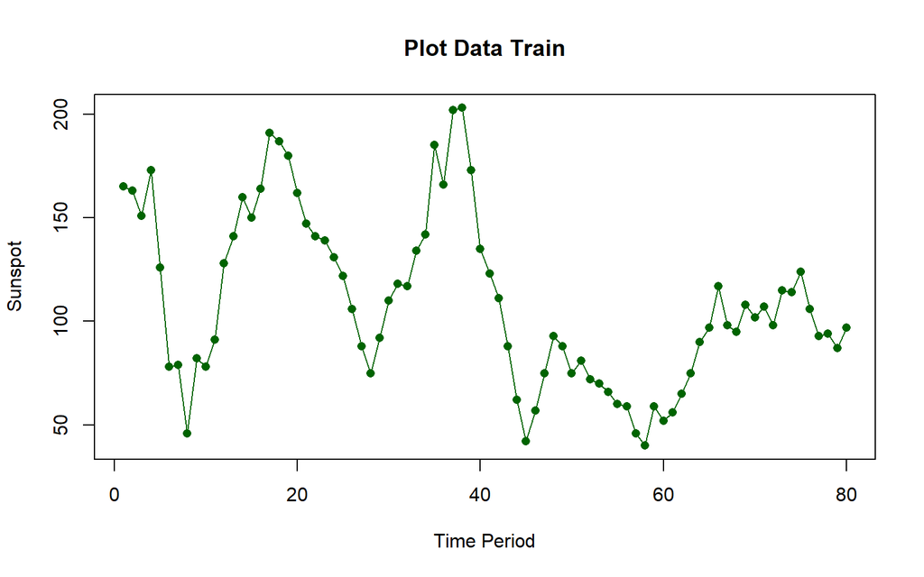

```r
ts.plot(train_ss.ts, col = "darkgreen", xlab = "Time Period",
        ylab = "Sunspot", main = "Plot Data Train")

points(train_ss.ts, col = "darkgreen", pch = 16)
```

## Plot Data Test

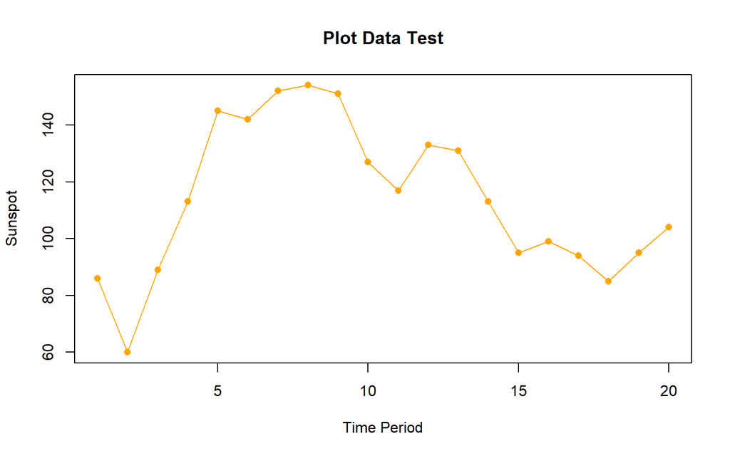

```r
ts.plot(test_ss.ts, col = "orange", xlab = "Time Period",
        ylab = "Sunspot", main = "Plot Data Test")

points(test_ss.ts, col = "orange", pch = 16)
```

## Plot Final

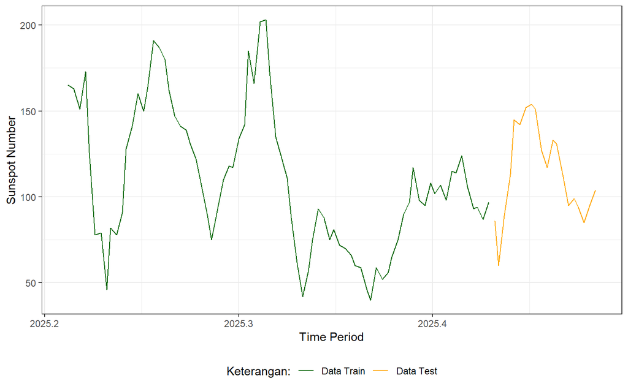

```r
ggplot() +
  geom_line(
    data = training_ss,
    aes(x = `Decimal Date`, y = `Sunspot Number`, col = "Data Train")
  ) +
  geom_line(
    data = testing_ss,
    aes(x = `Decimal Date`, y = `Sunspot Number`, col = "Data Test")
  ) +
  labs(
    x = "Time Period",
    y = "Sunspot Number",
    color = "Legend"
  ) +
  scale_colour_manual(
    name = "Keterangan:",
    breaks = c("Data Train", "Data Test"),
    values = c(
      "Data Train" = "darkgreen",
      "Data Test" = "orange"
    )
  ) +
  theme_bw() +
  theme(
    legend.position = "bottom",
    plot.caption = element_text(hjust = 0.5, size = 12)
  )
```

# Single Moving Average & Double Moving Average

## Single Moving Average

### Forecasting

```r
sunspot_sma <- SMA(train_ss.ts, n = 4)
sunspot_fcast <- c(NA, sunspot_sma)

sunspot_final <- cbind(
  aktual = c(train_ss.ts, rep(NA, 20)),
  smoothing = c(sunspot_sma, rep(NA, 20)),
  forecast = c(sunspot_fcast,rep(sunspot_fcast[length(sunspot_fcast)], 19)
  )
)

sunspot_final
```

```
##        aktual smoothing forecast
##   [1,]    165        NA       NA
##   [2,]    163        NA       NA
##   [3,]    151        NA       NA
##   [4,]    173    163.00       NA
##   [5,]    126    153.25   163.00
##   [6,]     78    132.00   153.25
##   [7,]     79    114.00   132.00
##   [8,]     46     82.25   114.00
##   [9,]     82     71.25    82.25
##  [10,]     78     71.25    71.25
##  [11,]     91     74.25    71.25
##  [12,]    128     94.75    74.25
##  [13,]    141    109.50    94.75
##  [14,]    160    130.00   109.50
```

[output cut: 86 more lines]

### Plot forecast

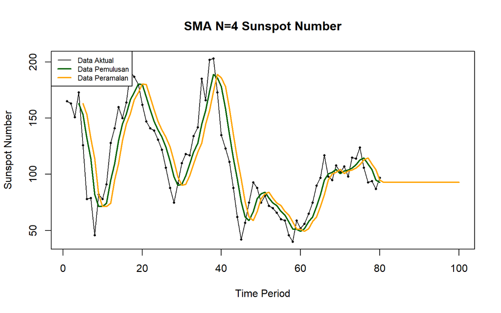

```r
ts.plot(
  sunspot_final[,1],
  xlab = "Time Period",
  ylab = "Sunspot Number",
  main = "SMA N=4 Sunspot Number",
  col = "black",
  lwd = 1
)

points(sunspot_final[,1], pch = 16, cex = 0.5)

lines(sunspot_final[,2], col = "darkgreen", lwd = 2)
lines(sunspot_final[,3], col = "orange", lwd = 2)

legend(
  "topleft",
  c("Data Aktual", "Data Pemulusan", "Data Peramalan"),
  lty = 1,
  col = c("black", "darkgreen", "orange"),
  lwd = c(1, 2, 2),
  cex = 0.7
)
```

### Data Train Accuration

```r
error_train.sma <- train_ss.ts - sunspot_fcast[1:length(train_ss.ts)]

SSE_train.sma <- sum(error_train.sma[5:length(train_ss.ts)]^2)
MSE_train.sma <- mean(error_train.sma[5:length(train_ss.ts)]^2)
MAPE_train.sma <- mean(abs((error_train.sma[5:length(train_ss.ts)] /
                              train_ss.ts[5:length(train_ss.ts)]) * 100))

acc_train.sma <- matrix(
  c(SSE_train.sma, MSE_train.sma, MAPE_train.sma)
)

row.names(acc_train.sma) <- c("SSE", "MSE", "MAPE")
colnames(acc_train.sma) <- c("Accuration m = 4")

acc_train.sma
```

```
##      Accuration m = 4
## SSE       65132.75000
## MSE         857.00987
## MAPE         24.82302
```

Nilai akurasi data train diperoleh sebesar $SSE = 65132.75$, $MSE = 857.01$, dan $MAPE = 24.82\%$. Berdasarkan nilai MAPE tersebut, metode Simple Moving Average dengan $m=4$ memiliki tingkat akurasi yang tergolong cukup.

### Data Test Accuration

```r
start_test <- n_train + 1
end_test <- n_train + length(test_ss.ts)

error_test.sma <- test_ss.ts -
  sunspot_final[start_test:end_test, "forecast"]

SSE_test.sma <- sum(error_test.sma^2)
MSE_test.sma <- mean(error_test.sma^2)
MAPE_test.sma <- mean(abs((error_test.sma / test_ss.ts) * 100))

acc_test.sma <- matrix(c(SSE_test.sma, MSE_test.sma, MAPE_test.sma))

row.names(acc_test.sma) <- c("SSE", "MSE", "MAPE")
colnames(acc_test.sma) <- c("Accuraton m = 4")

acc_test.sma
```

```
##      Accuraton m = 4
## SSE      22844.75000
## MSE       1142.23750
## MAPE        21.50022
```

Nilai akurasi data test diperoleh sebesar $SSE = 22844.75$, $MSE = 1142.238$, dan $MAPE = 21.5\%$. Berdasarkan nilai MAPE tersebut, metode Simple Moving Average dengan $m=4$ memiliki tingkat akurasi yang tergolong cukup.

## Double Moving Average

### Forecasting

```r
sunspot_sma <- SMA(train_ss.ts, n = 4)
sunspot_dma <- SMA(sunspot_sma, n = 4)

At <- 2 * sunspot_sma - sunspot_dma
Bt <- 2 / (4 - 1) * (sunspot_sma - sunspot_dma)

sunspot_dma_final <- At + Bt
sunspot_fcast_dma <- c(NA, sunspot_dma_final)

t <- 1:20
f <- c()

for (i in t) {
  f[i] <- At[length(At)] + Bt[length(Bt)] * i
}

sunspot_final_dma <- cbind(
  aktual = c(sunspot_ts),
  smoothing1 = c(sunspot_sma, rep(NA, 20)),
  smoothing2 = c(sunspot_dma, rep(NA, 20)),
  At = c(At, rep(NA, 20)),
  Bt = c(Bt, rep(NA, 20)),
  forecast = c(sunspot_fcast_dma, f[-1])
)

sunspot_final_dma
```

```
##        aktual smoothing1 smoothing2       At          Bt    forecast
##   [1,]    165         NA         NA       NA          NA          NA
##   [2,]    163         NA         NA       NA          NA          NA
##   [3,]    151         NA         NA       NA          NA          NA
##   [4,]    173     163.00         NA       NA          NA          NA
##   [5,]    126     153.25         NA       NA          NA          NA
##   [6,]     78     132.00         NA       NA          NA          NA
##   [7,]     79     114.00   140.5625  87.4375 -17.7083333          NA
##   [8,]     46      82.25   120.3750  44.1250 -25.4166667  69.7291667
##   [9,]     82      71.25    99.8750  42.6250 -19.0833333  18.7083333
##  [10,]     78      71.25    84.6875  57.8125  -8.9583333  23.5416667
##  [11,]     91      74.25    74.7500  73.7500  -0.3333333  48.8541667
##  [12,]    128      94.75    77.8750 111.6250  11.2500000  73.4166667
##  [13,]    141     109.50    87.4375 131.5625  14.7083333 122.8750000
##  [14,]    160     130.00   102.1250 157.8750  18.5833333 146.2708333
```

[output cut: 86 more lines]

### Plot forecast

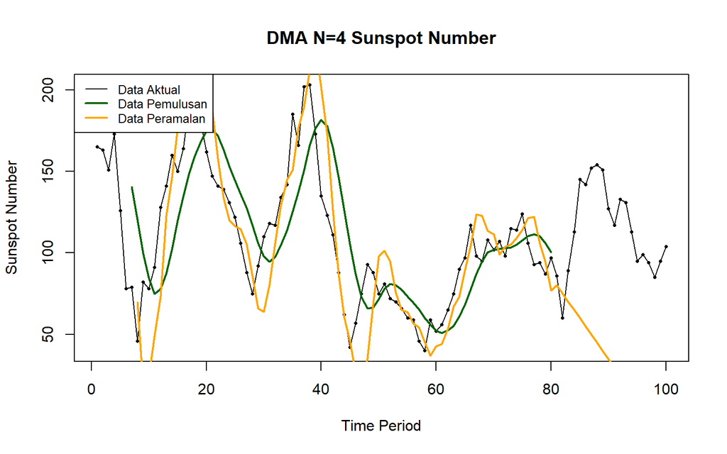

```r
ts.plot(sunspot_final_dma[,1],
  xlab = "Time Period",
  ylab = "Sunspot Number",
  main = "DMA N=4 Sunspot Number",
  col = "black"
)

points(sunspot_final_dma[,1],pch = 16,cex = 0.5)
lines(sunspot_final_dma[,3],col = "darkgreen",lwd = 2)
lines(sunspot_final_dma[,6],col = "orange",lwd = 2)

legend("topleft",c("Data Aktual", "Data Pemulusan", "Data Peramalan"),
  lty = 1,
  col = c("black", "darkgreen", "orange"),
  lwd = c(1, 2, 2),
  cex = 0.8
)
```

### Data Train Accuration

```r
error_train.dma <- train_ss.ts - sunspot_fcast_dma[1:length(train_ss.ts)]

SSE_train.dma <- sum(error_train.dma[8:length(train_ss.ts)]^2)
MSE_train.dma <- mean(error_train.dma[8:length(train_ss.ts)]^2)
MAPE_train.dma <- mean(abs((error_train.dma[8:length(train_ss.ts)] /
       train_ss.ts[8:length(train_ss.ts)]) * 100))

acc_train.dma <- matrix(c(SSE_train.dma, MSE_train.dma, MAPE_train.dma))

row.names(acc_train.dma) <- c("SSE", "MSE", "MAPE")
colnames(acc_train.dma) <- c("Akurasi m = 4")

acc_train.dma
```

```
##      Akurasi m = 4
## SSE    48681.64280
## MSE      666.87182
## MAPE      20.01973
```

Nilai akurasi data train diperoleh sebesar $SSE = 48681.643$, $MSE = 666.872$, dan $MAPE = 20\%$. Berdasarkan nilai MAPE tersebut, metode Double Moving Average dengan $m=4$ memiliki tingkat akurasi yang tergolong cukup.

### Data Test Accuration

```r
start_test <- n_train + 1
end_test <- n_train + length(test_ss.ts)

error_test.dma <- test_ss.ts -sunspot_final_dma[start_test:end_test, "forecast"]

SSE_test.dma <- sum(error_test.dma^2)
MSE_test.dma <- mean(error_test.dma^2)
MAPE_test.dma <- mean(abs((error_test.dma / test_ss.ts) * 100))

acc_test.dma <- matrix(c(SSE_test.dma, MSE_test.dma, MAPE_test.dma))

row.names(acc_test.dma) <- c("SSE", "MSE", "MAPE")
colnames(acc_test.dma) <- c("Akurasi m = 4")

acc_test.dma
```

```
##      Akurasi m = 4
## SSE    161196.6962
## MSE      8059.8348
## MAPE       72.3374
```

Nilai akurasi data test diperoleh sebesar $SSE = 161196.7$, $MSE = 8059.83$, dan $MAPE = 72.34\%$. Berdasarkan nilai MAPE tersebut, metode Double Moving Average dengan $m=4$ memiliki tingkat akurasi yang tergolong buruk.

# Single Exponential Smoothing & Double Exponential Smoothing

## Single Exponential Smoothing

### SES Modeling

```r
ses_02 <- ses(train_ss.ts,h = 20,alpha = 0.2)
ses_07 <- ses(train_ss.ts,h = 20,alpha = 0.7)
ses_opt <- ses(train_ss.ts,h = 20,alpha = NULL)

ses_opt$model$par["alpha"]
```

```
##  alpha
## 0.9999
```

### Plot SES

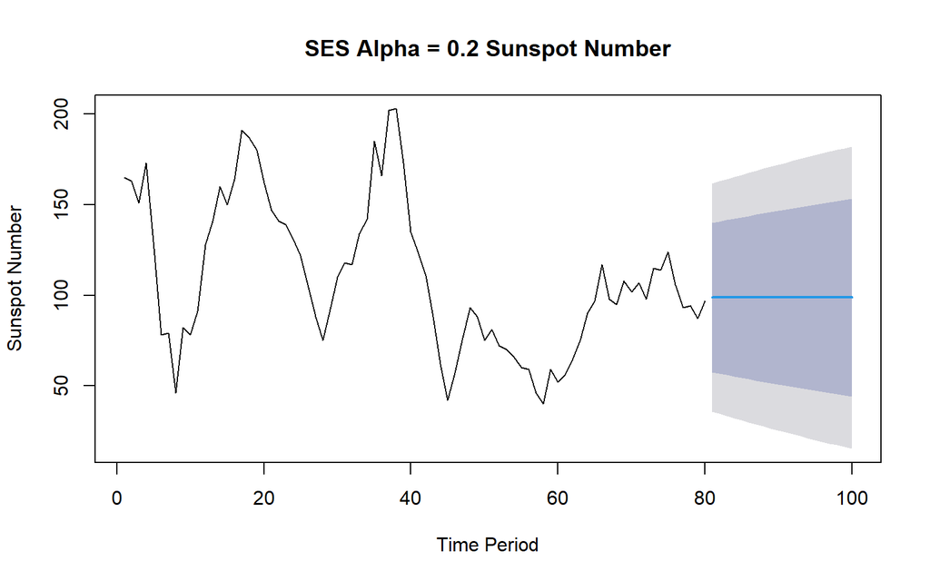

```r
plot(ses_02,main = "SES Alpha = 0.2 Sunspot Number",xlab = "Time Period",ylab = "Sunspot Number")
```

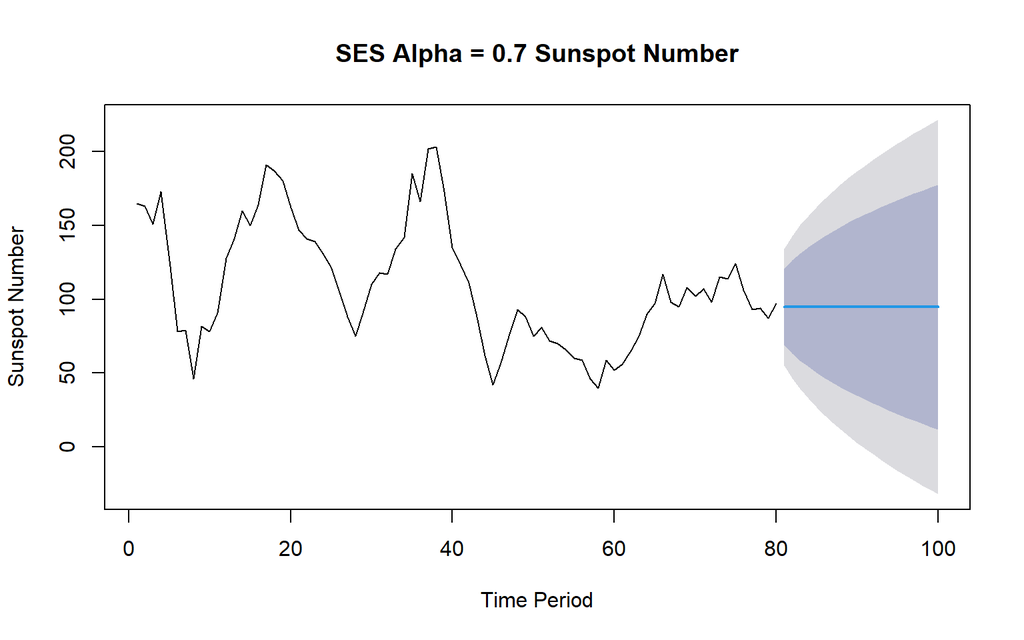

```r
plot(ses_07,main = "SES Alpha = 0.7 Sunspot Number",xlab = "Time Period",ylab = "Sunspot Number")
```

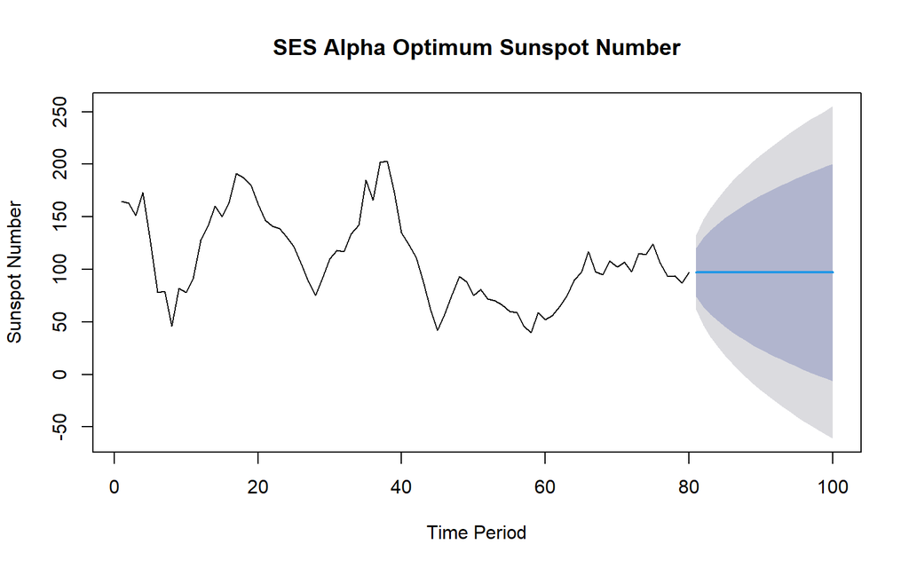

```r
plot(ses_opt,main = "SES Alpha Optimum Sunspot Number",xlab = "Time Period",ylab = "Sunspot Number")
```

### Accuration Data Train

```r
error_train.ses02 <- residuals(ses_02)

SSE_train.ses02 <- sum(error_train.ses02^2, na.rm = TRUE)
MSE_train.ses02 <- mean(error_train.ses02^2, na.rm = TRUE)
MAPE_train.ses02 <- mean(abs((error_train.ses02 / train_ss.ts) * 100),na.rm = TRUE)
```

```r
error_train.ses07 <- residuals(ses_07)

SSE_train.ses07 <- sum(error_train.ses07^2, na.rm = TRUE)
MSE_train.ses07 <- mean(error_train.ses07^2, na.rm = TRUE)
MAPE_train.ses07 <- mean(abs((error_train.ses07 / train_ss.ts) * 100),na.rm = TRUE)
```

```r
error_train.sesopt <- residuals(ses_opt)

SSE_train.sesopt <- sum(error_train.sesopt^2, na.rm = TRUE)
MSE_train.sesopt <- mean(error_train.sesopt^2, na.rm = TRUE)
MAPE_train.sesopt <- mean(abs((error_train.sesopt / train_ss.ts) * 100),na.rm = TRUE)
```

```r
acc_train.ses <- data.frame(
  Metode = c("Alpha = 0.2",
             "Alpha = 0.7",
             "Alpha Optimum"),

  SSE = c(SSE_train.ses02,
          SSE_train.ses07,
          SSE_train.sesopt),

  MSE = c(MSE_train.ses02,
          MSE_train.ses07,
          MSE_train.sesopt),

  MAPE = c(MAPE_train.ses02,
           MAPE_train.ses07,
           MAPE_train.sesopt)
)

acc_train.ses
```

```
##          Metode      SSE       MSE     MAPE
## 1   Alpha = 0.2 80417.08 1005.2135 27.43450
## 2   Alpha = 0.7 31642.70  395.5338 16.41895
## 3 Alpha Optimum 25404.81  317.5602 14.46526
```

### Accuration Data Test

```r
aktual_test <- as.numeric(test_ss.ts)

pred_ses02  <- as.numeric(ses_02$mean)
pred_ses07  <- as.numeric(ses_07$mean)
pred_sesopt <- as.numeric(ses_opt$mean)
```

```r
error_test.ses02  <- aktual_test - pred_ses02
error_test.ses07  <- aktual_test - pred_ses07
error_test.sesopt <- aktual_test - pred_sesopt

SSE_test.ses02 <- sum(error_test.ses02^2)
MSE_test.ses02 <- mean(error_test.ses02^2)
MAPE_test.ses02 <- mean(abs(error_test.ses02 / aktual_test) * 100)

SSE_test.ses07 <- sum(error_test.ses07^2)
MSE_test.ses07 <- mean(error_test.ses07^2)
MAPE_test.ses07 <- mean(abs(error_test.ses07 / aktual_test) * 100)

SSE_test.sesopt <- sum(error_test.sesopt^2)
MSE_test.sesopt <- mean(error_test.sesopt^2)
MAPE_test.sesopt <- mean(abs(error_test.sesopt / aktual_test) * 100)
```

```r
akurasi_test.ses <- data.frame(
  Metode = c("Alpha = 0.2", "Alpha = 0.7", "Alpha Optimum"),
  SSE = c(SSE_test.ses02, SSE_test.ses07, SSE_test.sesopt),
  MSE = c(MSE_test.ses02, MSE_test.ses07, MSE_test.sesopt),
  MAPE = c(MAPE_test.ses02, MAPE_test.ses07, MAPE_test.sesopt)
)

akurasi_test.ses
```

```
##          Metode      SSE       MSE     MAPE
## 1   Alpha = 0.2 18432.96  921.6478 20.30892
## 2   Alpha = 0.7 21209.43 1060.4713 20.75168
## 3 Alpha Optimum 19551.69  977.5845 20.47638
```

### Plot Alpha Optimum

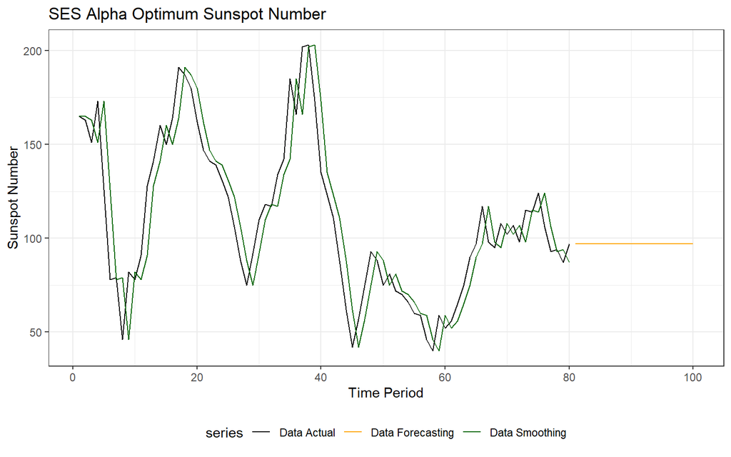

```r
autoplot(train_ss.ts, series = "Data Actual") +
  autolayer(fitted(ses_opt), series = "Data Smoothing") +
  autolayer(ses_opt$mean, series = "Data Forecasting") +
  xlab("Time Period") +
  ylab("Sunspot Number") +
  ggtitle("SES Alpha Optimum Sunspot Number") +
  scale_colour_manual(
    values = c(
      "Data Actual" = "black",
      "Data Smoothing" = "darkgreen",
      "Data Forecasting" = "orange"
    )
  ) +
  theme_bw() +
  theme(legend.position = "bottom")
```

## Double Exponential Smoothing

### DES Modeling

```r
des_02 <- HoltWinters(train_ss.ts,alpha = 0.2,beta = 0.2,gamma = FALSE)
des_06 <- HoltWinters(train_ss.ts,alpha = 0.6,beta = 0.3,gamma = FALSE)
des_opt <- HoltWinters(train_ss.ts,gamma = FALSE)

des_opt$alpha
```

```
## alpha
##     1
```

```r
des_opt$beta
```

```
## beta
##    0
```

### Forecasting

```r
(forecast_des02 <- forecast(des_02, h = 20))
```

```
##     Point Forecast      Lo 80    Hi 80       Lo 95    Hi 95
##  81      107.71570  56.143939 159.2875   28.843496 186.5879
##  82      106.79457  53.758332 159.8308   25.682644 187.9065
##  83      105.87344  50.906548 160.8403   21.808835 189.9380
##  84      104.95230  47.561479 162.3431   17.180612 192.7240
##  85      104.03117  43.712045 164.3503   11.781028 196.2813
##  86      103.11004  39.360994 166.8591    5.614289 200.6058
##  87      102.18890  34.521718 169.8561   -1.299127 205.6769
##  88      101.26777  29.214799 173.3207   -8.927741 211.4633
##  89      100.34664  23.464915 177.2284  -17.233811 217.9271
##  90       99.42550  17.298380 181.5526  -26.177094 225.0281
##  91       98.50437  10.741409 186.2673  -35.717497 232.7262
##  92       97.58324   3.819018 191.3475  -45.816761 240.9832
##  93       96.66210  -3.445585 196.7698  -56.439396 249.7636
##  94       95.74097 -11.031266 202.5132  -67.553074 259.0350
##  95       94.81984 -18.918997 208.5587  -79.128700 268.7684
##  96       93.89870 -27.091777 214.8892  -91.140269 278.9377
##  97       92.97757 -35.534465 221.4896 -103.564628 289.5198
##  98       92.05644 -44.233599 228.3465 -116.381186 300.4941
##  99       91.13530 -53.177201 235.4478 -129.571627 311.8422
## 100       90.21417 -62.354599 242.7829 -143.119628 323.5480
```

```r
(forecast_des06 <- forecast(des_06, h = 20))
```

```
##     Point Forecast       Lo 80    Hi 80       Lo 95    Hi 95
##  81       89.36934   60.561624 118.1771   45.311739 133.4269
##  82       86.89290   50.358174 123.4276   31.017856 142.7680
##  83       84.41646   38.594982 130.2379   14.338555 154.4944
##  84       81.94002   25.565152 138.3149   -4.277904 168.1580
##  85       79.46359   11.462722 147.4644  -24.534760 183.4619
##  86       76.98715   -3.581817 157.5561  -46.232450 200.2067
##  87       74.51071  -19.476656 168.4981  -69.230561 218.2520
##  88       72.03427  -36.153964 180.2225  -93.425354 237.4939
##  89       69.55783  -53.561388 192.6770 -118.736764 257.8524
##  90       67.08139  -71.657016 205.8198 -145.100692 279.2635
##  91       64.60495  -90.406278 219.6162 -172.464266 301.6742
##  92       62.12851 -109.779969 234.0370 -200.782820 325.0398
##  93       59.65207 -129.752931 249.0571 -230.017882 349.3220
##  94       57.17563 -150.303152 264.6544 -260.135786 374.4870
##  95       54.69919 -171.411124 280.8095 -291.106695 400.5051
##  96       52.22275 -193.059369 297.5049 -322.903880 427.3494
##  97       49.74631 -215.232090 314.7247 -355.503184 454.9958
##  98       47.26987 -237.914904 332.4547 -388.882606 483.4224
##  99       44.79343 -261.094625 350.6815 -423.021982 512.6089
## 100       42.31700 -284.759102 369.3931 -457.902728 542.5367
```

```r
(forecast_desopt <- forecast(des_opt, h = 20))
```

```
##     Point Forecast      Lo 80    Hi 80       Lo 95    Hi 95
##  81             95  71.749643 118.2504   59.441648 130.5584
##  82             93  60.119030 125.8810   42.712896 143.2871
##  83             91  50.729201 131.2708   29.411127 152.5889
##  84             89  42.499287 135.5007   17.883296 160.1167
##  85             87  35.010622 138.9894    7.489107 166.5109
##  86             85  28.048490 141.9515   -2.099819 172.0998
##  87             83  21.485338 144.5147  -11.078557 177.0786
##  88             81  15.238060 146.7619  -19.574208 181.5742
##  89             79   9.248930 148.7511  -27.675056 185.6751
##  90             77   3.475916 150.5241  -35.445383 189.4454
##  91             75  -2.112710 152.1127  -42.933712 192.9337
##  92             73  -7.541598 153.5416  -50.177745 196.1777
##  93             71 -12.830353 154.8304  -57.207462 199.2075
##  94             69 -17.994869 155.9949  -64.047171 202.0472
##  95             67 -23.048244 157.0482  -70.716906 204.7169
##  96             65 -28.001427 158.0014  -77.233409 207.2334
##  97             63 -32.863677 158.8637  -83.610842 209.6108
##  98             61 -37.642910 159.6429  -89.861312 211.8613
##  99             59 -42.345955 160.3460  -95.995264 213.9953
## 100             57 -46.978756 160.9788 -102.021785 216.0218
```